# Downloading and using data from clinicaltrials.gov

Michael C Sachs

2014-11-25

## R interface to clinicaltrials.gov

[Clinicaltrials.gov](http://clinicaltrials.gov) ClinicalTrials.gov is a registry and results database of publicly and privately supported clinical studies of human participants conducted around the world. Users can search for information about and results from those trials. This package provides a set of functions to interact with the search and download features. Results are downloaded to temporary directories and returned as R objects.

### Installation

The package is not currently available on [CRAN](http://cran.r-project.org). To install, use `devtools::install_github()`, as follows:

```r
install.packages("devtools")
library(devtools)
install_github("sachsmc/rclinicaltrials")
```

### Basic usage

The main function is `clinicaltrials_search()`. Here’s an example of its use:

```r
library(rclinicaltrials)
z <- clinicaltrials_search(query = 'lime+disease')
str(z)
```

```
## 'data.frame':    17 obs. of  8 variables:
##  $ score               : chr  "0.040837" "0.028325" "0.020444" "0.016984" ...
##  $ nct_id              : chr  "NCT01333202" "NCT01951924" "NCT01056133" "NCT02156089" ...
##  $ url                 : chr  "http://ClinicalTrials.gov/show/NCT01333202" "http://ClinicalTrials.gov/show/NCT01951924" "http://ClinicalTrials.gov/show/NCT01056133" "http://ClinicalTrials.gov/show/NCT02156089" ...
##  $ title               : chr  "Fresh Lime Alone for Smoking Cessation" "LIME Study (LFB IVIG MMN Efficacy Study)" "Effect of Fish-oil on Non-alcoholic Steatohepatitis (NASH)" "Neuroimaging, Omega-3 and Reward in Adults With ADHD (NORAA) Trial" ...
##  $ status.text         : chr  "Completed" "Recruiting" "Recruiting" "Recruiting" ...
##  $ condition_summary   : chr  "Tobacco Use Disorder" "Motor Neuron Disease" "Non-alcoholic Fatty Liver Disease; Non-alcoholic Steatohepatitis" "Attention Deficit Disorder; Attention Deficit Hyerpactivity Disorder" ...
##  $ intervention_summary: chr  "Other: Fresh lime" "Drug: Biological : I10E (Human normal Immunoglobulin for intravenous administration 100mg/mL); Drug: Biological: Kiovig® (Human"| __truncated__ "Other: Omega-3 capsules-Fish Oil" "Other: Highly unsaturated omega-3 fatty acids" ...
##  $ last_changed        : chr  "April 8, 2011" "October 22, 2014" "May 23, 2014" "November 8, 2014" ...
```

This gives you basic information about the trials. Before searching or downloading, you can determine how many results will be returned using the `clinicaltrials_count()` function:

```r
clinicaltrials_count(query = "myeloma")
```

```
## [1] 1876
```

```r
clinicaltrials_count(query = "29485tksrw@")
```

```
## [1] 0
```

The query can be a single string which will be passed to the “search terms” field on clinicaltrials.gov. Terms can be combined using the logical operators AND, OR, and NOT. Advanced searches can be performed by passing a vector of key=value pairs as strings. For example, to search for cancer interventional studies,

```r
clinicaltrials_count(query = c("type=Intr", "cond=cancer"))
```

```
## [1] 35850
```

The possible advance search terms are included in the `advanced_search_terms` data frame which comes with the package. The data frame has the keys, description, and a link to the help webpage which will explain the possible values of the search terms. To open the help page for `cond`, for instance, run `browseURL(advanced_search_terms["cond", "help"])`.

```r
head(advanced_search_terms)
```

```
##      keys   description
## term term  Search Terms
## recr recr   Recruitment
## rslt rslt Study Results
## type type    Study Type
## cond cond    Conditions
## intr intr Interventions
##                                                        help
## term        http://clinicaltrials.gov/ct2/help/search_terms
## recr         http://clinicaltrials.gov/ct2/help/recruitment
## rslt       http://clinicaltrials.gov/ct2/help/study_results
## type          http://clinicaltrials.gov/ct2/help/study_type
## cond    http://clinicaltrials.gov/ct2/help/conditions_instr
## intr http://clinicaltrials.gov/ct2/help/interventions_instr
```

To download detailed study information, including results, use `clinicaltrials_download()`:

```r
y <- clinicaltrials_download(query = 'myeloma', count = 10, include_results = TRUE)
str(y)
```

```
## List of 2
##  $ study_information:List of 6
##   ..$ study_info   :'data.frame':    10 obs. of  45 variables:
##   .. ..$ org_study_id                        : chr [1:10] "000201" "CDR0000597015" "MCC-15697" "HCI33979" ...
##   .. ..$ nct_id                              : chr [1:10] "NCT00006184" "NCT00897910" "NCT00948922" "NCT00983346" ...
##   .. ..$ brief_title                         : chr [1:10] "Chemotherapy, Stem Cell Transplantation and Donor and Patient Vaccination for Treatment of Multiple Myeloma" "Studying T Cells in Blood and Bone Marrow Samples From Patients With Multiple Myeloma" "Melphalan+Bortezomib as a Conditioning R…
##   .. ..$ official_title                      : chr [1:10] "Active Immunization of Sibling Stem Cell Transplant Donors Against Purified Myeloma Protein of the Stem Cell Recipient With Mul"| __truncated__ "Strategies to Isolate and Expand Myeloma Specific T-cells Using Autologous B Cells as Antigen…
##   .. ..$ overall_status                      : chr [1:10] "Completed" "Terminated" "Recruiting" "Completed" ...
##   .. ..$ start_date                          : chr [1:10] "August 2000" "April 2008" "June 2009" "October 2009" ...
##   .. ..$ completion_date.text                : chr [1:10] "July 2013" "September 2012" "May 2015" "September 2014" ...
##   .. ..$ completion_date..attrs              : chr [1:10] "Actual" "Actual" "Anticipated" "Actual" ...
##   .. ..$ completion_date_type                : chr [1:10] "Actual" "Actual" "Anticipated" "Actual" ...
##   .. ..$ lead_sponsor/agency                 : chr [1:10] "National Cancer Institute (NCI)" "Barbara Ann Karmanos Cancer Institute" "H. Lee Moffitt Cancer Center and Research Institute" "University of Utah" ...
##   .. ..$ overall_official.last_name          : chr [1:10] "Claude Sportes, M.D." "Zaid Al-Kadhimi, MD" "Melissa Alsina, MD" "Maurizio Zangari, MD" ...
##   .. ..$ overall_official.role               : chr [1:10] "Principal Investigator" "Principal Investigator" "Principal Investigator" "Principal Investigator" ...
##   .. ..$ overall_official.affiliation        : chr [1:10] "National Cancer Institute (NCI)" "Barbara Ann Karmanos Cancer Institute" "H. Lee Moffitt Cancer Center and Research Institute" "University of Utah" ...
##   .. ..$ phase                               : chr [1:10] "Phase 2" "N/A" "Phase 2" "Phase 2" ...
##   .. ..$ study_type                          : chr [1:10] "Interventional" "Observational" "Interventional" "Interventional" ...
##   .. ..$ study_design                        : chr [1:10] "Allocation: Non-Randomized, Endpoint Classification: Safety/Efficacy Study, Intervention Model: Parallel Assignment, Masking: O"| __truncated__ "Observational Model: Case-Only, Time Perspective: Prospective" "Allocation: Non-Randomized, E…
##   .. ..$ enrollment.text                     : chr [1:10] "20" "6" "150" "17" ...
##   .. ..$ enrollment..attrs                   : chr [1:10] "Actual" "Actual" "Anticipated" "Actual" ...
##   .. ..$ primary_condition                   : chr [1:10] "Multiple Myeloma" "Multiple Myeloma and Plasma Cell Neoplasm" "Multiple Myeloma" "Cancer" ...
##   .. ..$ primary_outcome.measure             : chr [1:10] "Immune Response" "Percentage of Myeloma-specific T Cells ex Vivo Expanded Using Flow Cytometry" "Progression Free Survival (PFS) - Allogeneic Stem Cell Transplant in Multiple Myeloma Arm" "To evaluate the bone anabolic effect of bortezomi…
##   .. ..$ primary_outcome.time_frame          : chr [1:10] "105 days" "Collection of PBMCs over a period of 9-12 months, and the laboratory component will be performed over another year." "2 years" "September 2012" ...
##   .. ..$ primary_outcome.safety_issue        : chr [1:10] "No" "No" "No" "No" ...
##   .. ..$ primary_outcome.description         : chr [1:10] "Immune cell depletion is defined as immunosuppression of participants T cells prior to transplant measured by cluster of differ"| __truncated__ NA "PFS with allogeneic stem cell transplant using melphalan+fludarabine+bortezomib as the con…
```

[output cut: 86 more lines]

This returns a list of dataframes that have a common key variable: `nct_id`. Optionally, you can get the long text fields and/or study results (if available). Study results are also returned as a list of dataframes, contained within the list.

### How to use the results

The data come from a relational database with lots of text fields, so it may take some effort to get the data into a flat format for analysis. For that reason, results come back from the `clinicaltrials_download` function as a list of dataframes. Each dataframe has a common key variable: `nct_id`. To merge dataframes, use this key. Otherwise, you can analyze the dataframes separately. They are organized into study information, locations, outcomes, interventions, results, and textblocks. Results, where available, is itself a list with three dataframes: participant flow, baseline data, and outcome data.

Results tables are stored in long format, so there are often multiple rows per study, each corresponding to a different group or outcome. Let’s look at an example, the cumulative enrollment of men and women in phase III, melanoma, interventional studies over time.

```r
melanom <- clinicaltrials_search(query = c("cond=melanoma", "phase=2",
                                           "type=Intr", "rslt=With"),
                                 count = 1e6)
nrow(melanom)
```

```
## [1] 18
```

```r
table(melanom$status.text)
```

```
##
## Active, not recruiting              Completed             Terminated
##                      6                     11                      1
```

Now to download the data:

```r
melanom_information <- clinicaltrials_download(query = c("cond=melanoma", "phase=2",
                                                         "type=Intr", "rslt=With"),
                                               count = 1e6, include_results = TRUE)
summary(melanom_information$study_results$baseline_data)
```

```
##                         title              units        param
##  Gender                    :104   participants:421   Number:524
##  Region of Enrollment      : 83   years       : 41   Median: 16
##  Age                       : 73   Participants:103   Mean  : 34
##  Number of Participants    : 52   Years       :  9
##  Race/Ethnicity, Customized: 37
##  Age, Customized           : 23
##  (Other)                   :202
##    subtitle           group_id            value
##  Length:574         Length:574         Length:574
##  Class :character   Class :character   Class :character
##  Mode  :character   Mode  :character   Mode  :character
##
##
##
##
##               dispersion  lower_limit        upper_limit
##  Full Range        : 28   Length:574         Length:574
##  Standard Deviation: 22   Class :character   Class :character
##  NA's              :524   Mode  :character   Mode  :character
##
##
##
##
##      arm               nct_id
##  Length:574         Length:574
##  Class :character   Class :character
##  Mode  :character   Mode  :character
##
##
##
##
##                                                                                                                                                                                                                                                                                                          …
##  The "M" in the TNM (tumor, node, metastasis) system refers to distant metastases—whether, and how far, the cancer has spread outside the original site. M0: There is no evidence that the cancer has spread beyond the original site. M1: The cancer has spread beyond the original site. M1a: The cance…
##  Breslow's Thickness is a measure of the vertical thickness of a cutaneous melanoma  lesion and is reported in millimeters (mm).                                                                                                                                                                         …
##  ECOG-Eastern Cooperative Oncology Group (ECOG) Performance Status is used by doctors and researchers to assess how a participant's disease is progressing, assess how the disease affects the daily living activities of the participant and determine appropriate treatment and prognosis. 0 = Fully Ac…
##  One patient on arm V had missing data for gender. Hence, a total of 189 patients on arm V reported gender.                                                                                                                                                                                              …
##  Upper limit of normal (ULN) was 250 U/L for most assessments (some variation caused by tests performed at local laboratories).                                                                                                                                                                          …
##  (Other)                                                                                                                                                                                                                                                                                                 …
##  NA's                                                                                                                                                                                                                                                                                                    …
##     spread
##  Length:574
##  Class :character
##  Mode  :character
##
##
##
##
```

```r
gend_data <- subset(melanom_information$study_results$baseline_data,
                    title == "Gender" & arm != "Total")

library(plyr)

gender_counts <- ddply(gend_data, ~ nct_id + subtitle, function(df){

  data.frame(
    count = sum(as.numeric(paste(df$value)), na.rm = TRUE)
    )

})
dates <- melanom_information$study_information$study_info[, c("nct_id", "start_date")]
dates$year <- sapply(strsplit(paste(dates$start_date), " "), function(d) as.numeric(d[2]))

counts <- merge(gender_counts, dates, by = "nct_id")
```

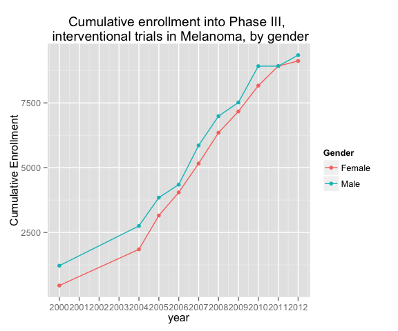

```r
library(ggplot2)
cts <- ddply(counts, ~ year + subtitle, summarize, count = sum(count))
colnames(cts)[2] <- "Gender"
ggplot(cts, aes(x = year, y = cumsum(count), color = Gender)) +
  geom_line() + geom_point() +
  labs(title = "Cumulative enrollment into Phase III, \n interventional trials in Melanoma, by gender") +
  scale_y_continuous("Cumulative Enrollment") +
  scale_x_continuous(breaks = 2000:2012)
```